# FluentVCF Vignettes

Mirco Macchi

2 dicembre 2022

#### Abstract

Instructions on using VCF package. Part of the code comes from professor Rosario M. Piro

#### Package

FluentVCF 0.1.0

Loading necessary libraries

```r
library(VariantAnnotation)
library(GenomicRanges)
library(BSgenome.Hsapiens.UCSC.hg38)
library(dplyr)
library(ggplot2)
library(RColorBrewer)
library(FluentVCF)
```

Reading the VCF file from VariantAnnotation package with human reference genome hg38

```r
require(VariantAnnotation)
vcffile <- system.file("extdata", "chr22.vcf.gz", package="VariantAnnotation")
vcf <- readVcf(vcffile, "hg38")
```

Inspecting the object

```r
class(vcf)
```

```
## [1] "CollapsedVCF"
## attr(,"package")
## [1] "VariantAnnotation"
```

Content of INFO fields:

```r
info(header(vcf))
```

```
## DataFrame with 22 rows and 3 columns
##                Number        Type            Description
##           <character> <character>            <character>
## LDAF                1       Float MLE Allele Frequency..
## AVGPOST             1       Float Average posterior pr..
## RSQ                 1       Float Genotype imputation ..
## ERATE               1       Float Per-marker Mutation ..
## THETA               1       Float Per-marker Transitio..
## ...               ...         ...                    ...
## ASN_AF              1       Float Allele Frequency for..
## AFR_AF              1       Float Allele Frequency for..
## EUR_AF              1       Float Allele Frequency for..
## VT                  1      String indicates what type ..
## SNPSOURCE           .      String indicates if a snp w..
```

```r
info(vcf)[1:3,1:5]
```

```
## DataFrame with 3 rows and 5 columns
##                  LDAF   AVGPOST       RSQ     ERATE     THETA
##             <numeric> <numeric> <numeric> <numeric> <numeric>
## rs7410291      0.3431    0.9890    0.9856     2e-03    0.0005
## rs147922003    0.0091    0.9963    0.8398     5e-04    0.0011
## rs114143073    0.0098    0.9891    0.5919     7e-04    0.0008
```

Genotype information (FORMAT and following columns of the VCF file):

```r
head(geno(vcf)$GT)
```

```
##             HG00096 HG00097 HG00099 HG00100 HG00101
## rs7410291   "0|0"   "0|0"   "1|0"   "0|0"   "0|0"
## rs147922003 "0|0"   "0|0"   "0|0"   "0|0"   "0|0"
## rs114143073 "0|0"   "0|0"   "0|0"   "0|0"   "0|0"
## rs141778433 "0|0"   "0|0"   "0|0"   "0|0"   "0|0"
## rs182170314 "0|0"   "0|0"   "0|0"   "0|0"   "0|0"
## rs115145310 "0|0"   "0|0"   "0|0"   "0|0"   "0|0"
```

In this way, all of the SNP’s are printed in format “rs———” , where “-” represents a number.

```r
rowRanges(vcf)
```

```
## GRanges object with 10376 ranges and 5 metadata columns:
##               seqnames    ranges strand | paramRangeID            REF
##                  <Rle> <IRanges>  <Rle> |     <factor> <DNAStringSet>
##     rs7410291       22  50300078      * |           NA              A
##   rs147922003       22  50300086      * |           NA              C
##   rs114143073       22  50300101      * |           NA              G
##   rs141778433       22  50300113      * |           NA              C
##   rs182170314       22  50300166      * |           NA              C
##           ...      ...       ...    ... .          ...            ...
##   rs187302552       22  50999536      * |           NA              A
##     rs9628178       22  50999538      * |           NA              A
##     rs5770892       22  50999681      * |           NA              A
##   rs144055359       22  50999830      * |           NA              G
##   rs114526001       22  50999964      * |           NA              G
##                              ALT      QUAL      FILTER
##               <DNAStringSetList> <numeric> <character>
##     rs7410291                  G       100        PASS
##   rs147922003                  T       100        PASS
##   rs114143073                  A       100        PASS
##   rs141778433                  T       100        PASS
##   rs182170314                  T       100        PASS
##           ...                ...       ...         ...
##   rs187302552                  G       100        PASS
##     rs9628178                  G       100        PASS
##     rs5770892                  G       100        PASS
##   rs144055359                  A       100        PASS
##   rs114526001                  C       100        PASS
##   -------
##   seqinfo: 1 sequence from hg38 genome; no seqlengths
```

Names of the reference sequences (here: chromosome 22)

```r
seqnames(vcf)
```

```
## factor-Rle of length 10376 with 1 run
##   Lengths: 10376
##   Values :    22
## Levels(1): 22
```

Start and end position on the reference sequence

```r
start(vcf[1:5])
```

```
## [1] 50300078 50300086 50300101 50300113 50300166
```

```r
end(vcf[1:5])
```

```
## [1] 50300078 50300086 50300101 50300113 50300166
```

DNA strand information

```r
as.character(strand(vcf[1:5]))
```

```
## [1] "*" "*" "*" "*" "*"
```

Extract the first 500 rows of the dataset

```r
vcfDF <- as(rowRanges(vcf[1:500]), "DataFrame")
head(vcfDF)
```

```
## DataFrame with 6 rows and 6 columns
##                       X paramRangeID            REF                ALT
##               <GRanges>     <factor> <DNAStringSet> <DNAStringSetList>
## rs7410291   22:50300078           NA              A                  G
## rs147922003 22:50300086           NA              C                  T
## rs114143073 22:50300101           NA              G                  A
## rs141778433 22:50300113           NA              C                  T
## rs182170314 22:50300166           NA              C                  T
## rs115145310 22:50300187           NA              G                  A
##                  QUAL      FILTER
##             <numeric> <character>
## rs7410291         100        PASS
## rs147922003       100        PASS
## rs114143073       100        PASS
## rs141778433       100        PASS
## rs182170314       100        PASS
## rs115145310       100        PASS
```

Extract and store unique mutations signatures present in the data with reference hg38. Default context length is set to 3. Thus, default output will be in “C[A>G]C” format.

```r
require(BSgenome.Hsapiens.UCSC.hg38)
Hsapiens <- BSgenome.Hsapiens.UCSC.hg38::BSgenome.Hsapiens.UCSC.hg38
muts <- mut_type(vcfDF, ref.genome = Hsapiens)
head(muts)
```

```
## [1] "C[A>G]C" "C[C>T]G" "C[G>A]C" "T[C>T]G" "G[G>A]G" "G[T>C]G"
```

The reference bases (=REF)

```r
refBase <- ref(vcf)
ref(vcf[1:5])
```

```
## DNAStringSet object of length 5:
##     width seq
## [1]     1 A
## [2]     1 C
## [3]     1 G
## [4]     1 C
## [5]     1 C
```

```r
refBase <- unlist(lapply(refBase, as.character))
refBase[1:2]
```

```
## [1] "A" "C"
```

The alternate (variant!) bases (=ALT)

```r
altBase <- alt(vcf)
alt(vcf[1:5])
```

```
## DNAStringSetList of length 5
## [[1]] G
## [[2]] T
## [[3]] A
## [[4]] T
## [[5]] T
```

get the 1st and 2nd vector of the list

```r
altBase <- lapply(altBase, '[[', 1)
altBase[1:2]
```

```
## [[1]]
## 1-letter DNAString object
## seq: G
##
## [[2]]
## 1-letter DNAString object
## seq: T
```

Convert DNAString object to character

```r
altBase <- unlist(lapply(altBase, as.character))
altBase[1:2]
```

```
## [1] "G" "T"
```

Get coordinates

```r
startRef <- start(vcf)
endRef <- end(vcf)
```

Chromosome number

```r
chr <- seqnames(vcf)
```

Collecting pieces of interest coming from original file will ease downstream steps

```r
Basedf <- data.frame(ref = refBase, alt=altBase, startRef= startRef, endRef= endRef, chr = chr)
head(Basedf)
```

```
##   ref alt startRef   endRef chr
## 1   A   G 50300078 50300078  22
## 2   C   T 50300086 50300086  22
## 3   G   A 50300101 50300101  22
## 4   C   T 50300113 50300113  22
## 5   C   T 50300166 50300166  22
## 6   G   A 50300187 50300187  22
```

Applying “type” function on the data frame, wil return the same inpu object with a new column listing the type for each mutation(substitution, insertion, deletion).

```r
Basedf$type <- apply(Basedf,1,type)
head(Basedf)
```

```
##   ref alt startRef   endRef chr type
## 1   A   G 50300078 50300078  22  sub
## 2   C   T 50300086 50300086  22  sub
## 3   G   A 50300101 50300101  22  sub
## 4   C   T 50300113 50300113  22  sub
## 5   C   T 50300166 50300166  22  sub
## 6   G   A 50300187 50300187  22  sub
```

With mut_summary, total number of mutation per type is extracted from the data set.

```r
mut_summary <- mut_summary(Basedf)
mut_summary
```

```
##   type    n
## 1  del  233
## 2  ins  174
## 3  sub 9969
```

MutHist Lastly, it is interesing to plot an informative histogram regarding mutation frequency in the dataset.

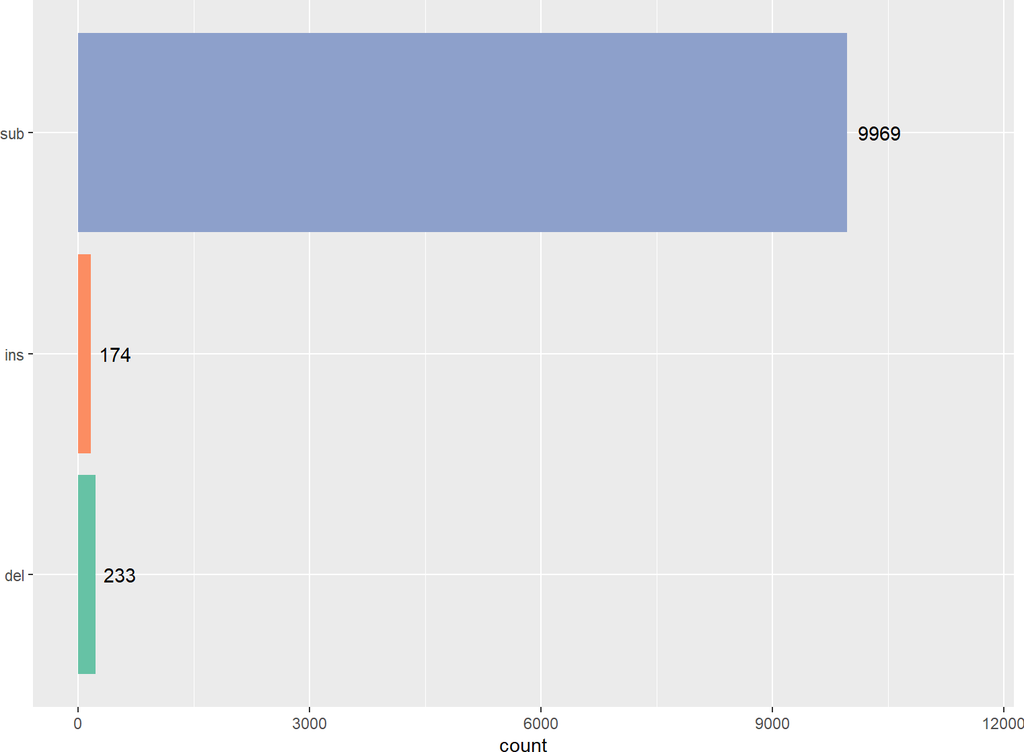

```r
MutHist(mut_summary)
```